# Risk Factor Analysis

## Outcome Variable

**Outcome Variable:** ever_stunted

## Predictor Variables

**Intervention Variable:** mbmi

**Adjustment Set:**

unadjusted

## Stratifying Variables

The analysis was stratified on these variable(s):

- agecat
- studyid
- country

## Data Summary

| agecat | studyid | country | mbmi | ever_stunted | n_cell | n |
| --- | --- | --- | --- | --- | --- | --- |
| 0-24 months | iLiNS-Zinc | BURKINA FASO | Normal weight | 0 | 1803 | 3216 |
| 0-24 months | iLiNS-Zinc | BURKINA FASO | Normal weight | 1 | 959 | 3216 |
| 0-24 months | iLiNS-Zinc | BURKINA FASO | Underweight | 0 | 266 | 3216 |
| 0-24 months | iLiNS-Zinc | BURKINA FASO | Underweight | 1 | 188 | 3216 |
| 0-24 months | JiVitA-3 | BANGLADESH | Normal weight | 0 | 8183 | 27105 |
| 0-24 months | JiVitA-3 | BANGLADESH | Normal weight | 1 | 8539 | 27105 |
| 0-24 months | JiVitA-3 | BANGLADESH | Underweight | 0 | 5491 | 27105 |
| 0-24 months | JiVitA-3 | BANGLADESH | Underweight | 1 | 4892 | 27105 |
| 0-24 months | LCNI-5 | MALAWI | Normal weight | 0 | 259 | 837 |
| 0-24 months | LCNI-5 | MALAWI | Normal weight | 1 | 433 | 837 |
| 0-24 months | LCNI-5 | MALAWI | Underweight | 0 | 46 | 837 |
| 0-24 months | LCNI-5 | MALAWI | Underweight | 1 | 99 | 837 |
| 0-24 months | MAL-ED | BANGLADESH | Normal weight | 0 | 89 | 254 |
| 0-24 months | MAL-ED | BANGLADESH | Normal weight | 1 | 133 | 254 |
| 0-24 months | MAL-ED | BANGLADESH | Underweight | 0 | 9 | 254 |
| 0-24 months | MAL-ED | BANGLADESH | Underweight | 1 | 23 | 254 |
| 0-24 months | MAL-ED | BRAZIL | Normal weight | 0 | 158 | 221 |
| 0-24 months | MAL-ED | BRAZIL | Normal weight | 1 | 53 | 221 |
| 0-24 months | MAL-ED | BRAZIL | Underweight | 0 | 6 | 221 |
| 0-24 months | MAL-ED | BRAZIL | Underweight | 1 | 4 | 221 |
| 0-24 months | MAL-ED | INDIA | Normal weight | 0 | 74 | 242 |
| 0-24 months | MAL-ED | INDIA | Normal weight | 1 | 119 | 242 |
| 0-24 months | MAL-ED | INDIA | Underweight | 0 | 19 | 242 |
| 0-24 months | MAL-ED | INDIA | Underweight | 1 | 30 | 242 |
| 0-24 months | MAL-ED | NEPAL | Normal weight | 0 | 155 | 238 |
| 0-24 months | MAL-ED | NEPAL | Normal weight | 1 | 83 | 238 |
| 0-24 months | MAL-ED | NEPAL | Underweight | 0 | 0 | 238 |
| 0-24 months | MAL-ED | NEPAL | Underweight | 1 | 0 | 238 |
| 0-24 months | MAL-ED | PERU | Normal weight | 0 | 102 | 290 |
| 0-24 months | MAL-ED | PERU | Normal weight | 1 | 183 | 290 |

[output cut: 170 more lines]

The following strata were considered:

- agecat: 0-24 months, studyid: iLiNS-Zinc, country: BURKINA FASO
- agecat: 0-24 months, studyid: JiVitA-3, country: BANGLADESH
- agecat: 0-24 months, studyid: LCNI-5, country: MALAWI
- agecat: 0-24 months, studyid: MAL-ED, country: BANGLADESH
- agecat: 0-24 months, studyid: MAL-ED, country: BRAZIL
- agecat: 0-24 months, studyid: MAL-ED, country: INDIA
- agecat: 0-24 months, studyid: MAL-ED, country: NEPAL
- agecat: 0-24 months, studyid: MAL-ED, country: PERU
- agecat: 0-24 months, studyid: MAL-ED, country: SOUTH AFRICA
- agecat: 0-24 months, studyid: MAL-ED, country: TANZANIA, UNITED REPUBLIC OF
- agecat: 0-24 months, studyid: NIH-Birth, country: BANGLADESH
- agecat: 0-24 months, studyid: NIH-Crypto, country: BANGLADESH
- agecat: 0-24 months, studyid: PROBIT, country: BELARUS
- agecat: 0-24 months, studyid: PROVIDE, country: BANGLADESH
- agecat: 0-24 months, studyid: SAS-CompFeed, country: INDIA
- agecat: 0-24 months, studyid: TanzaniaChild2, country: TANZANIA, UNITED REPUBLIC OF
- agecat: 0-24 months, studyid: ZVITAMBO, country: ZIMBABWE
- agecat: 0-6 months, studyid: JiVitA-3, country: BANGLADESH
- agecat: 0-6 months, studyid: LCNI-5, country: MALAWI
- agecat: 0-6 months, studyid: MAL-ED, country: BANGLADESH
- agecat: 0-6 months, studyid: MAL-ED, country: BRAZIL
- agecat: 0-6 months, studyid: MAL-ED, country: INDIA
- agecat: 0-6 months, studyid: MAL-ED, country: NEPAL
- agecat: 0-6 months, studyid: MAL-ED, country: PERU
- agecat: 0-6 months, studyid: MAL-ED, country: SOUTH AFRICA
- agecat: 0-6 months, studyid: MAL-ED, country: TANZANIA, UNITED REPUBLIC OF
- agecat: 0-6 months, studyid: NIH-Birth, country: BANGLADESH
- agecat: 0-6 months, studyid: NIH-Crypto, country: BANGLADESH
- agecat: 0-6 months, studyid: PROBIT, country: BELARUS
- agecat: 0-6 months, studyid: PROVIDE, country: BANGLADESH
- agecat: 0-6 months, studyid: SAS-CompFeed, country: INDIA
- agecat: 0-6 months, studyid: TanzaniaChild2, country: TANZANIA, UNITED REPUBLIC OF
- agecat: 0-6 months, studyid: ZVITAMBO, country: ZIMBABWE
- agecat: 6-24 months, studyid: iLiNS-Zinc, country: BURKINA FASO
- agecat: 6-24 months, studyid: JiVitA-3, country: BANGLADESH
- agecat: 6-24 months, studyid: LCNI-5, country: MALAWI
- agecat: 6-24 months, studyid: MAL-ED, country: BANGLADESH
- agecat: 6-24 months, studyid: MAL-ED, country: BRAZIL
- agecat: 6-24 months, studyid: MAL-ED, country: INDIA
- agecat: 6-24 months, studyid: MAL-ED, country: NEPAL
- agecat: 6-24 months, studyid: MAL-ED, country: PERU
- agecat: 6-24 months, studyid: MAL-ED, country: SOUTH AFRICA
- agecat: 6-24 months, studyid: MAL-ED, country: TANZANIA, UNITED REPUBLIC OF
- agecat: 6-24 months, studyid: NIH-Birth, country: BANGLADESH
- agecat: 6-24 months, studyid: NIH-Crypto, country: BANGLADESH
- agecat: 6-24 months, studyid: PROBIT, country: BELARUS
- agecat: 6-24 months, studyid: PROVIDE, country: BANGLADESH
- agecat: 6-24 months, studyid: SAS-CompFeed, country: INDIA
- agecat: 6-24 months, studyid: TanzaniaChild2, country: TANZANIA, UNITED REPUBLIC OF
- agecat: 6-24 months, studyid: ZVITAMBO, country: ZIMBABWE

### Dropped Strata

Some strata were dropped due to rare outcomes:

- agecat: 0-24 months, studyid: MAL-ED, country: BRAZIL
- agecat: 0-24 months, studyid: MAL-ED, country: NEPAL
- agecat: 0-24 months, studyid: MAL-ED, country: PERU
- agecat: 0-24 months, studyid: MAL-ED, country: SOUTH AFRICA
- agecat: 0-24 months, studyid: MAL-ED, country: TANZANIA, UNITED REPUBLIC OF
- agecat: 0-6 months, studyid: MAL-ED, country: BRAZIL
- agecat: 0-6 months, studyid: MAL-ED, country: NEPAL
- agecat: 0-6 months, studyid: MAL-ED, country: PERU
- agecat: 0-6 months, studyid: MAL-ED, country: SOUTH AFRICA
- agecat: 6-24 months, studyid: MAL-ED, country: BRAZIL
- agecat: 6-24 months, studyid: MAL-ED, country: NEPAL
- agecat: 6-24 months, studyid: MAL-ED, country: PERU
- agecat: 6-24 months, studyid: MAL-ED, country: SOUTH AFRICA
- agecat: 6-24 months, studyid: MAL-ED, country: TANZANIA, UNITED REPUBLIC OF

## Methods Detail

We’re interested in the causal parameters $E[Y_a]$ for all values of $a \in \mathcal{A}$. These parameters represent the mean outcome if, possibly contrary to fact, we intervened to set all units to have $A=a$. Under the randomization and positivity assumptions, these are identified by the statistical parameters $\psi_a=E_W[E_{Y|A,W}(Y|A=a,W)]$. In addition, we’re interested in the mean of $Y$, $E[Y]$ under no intervention (the observed mean). We will estimate these parameters by using SuperLearner to fit the relevant likelihood factors – $E_{Y|A,W}(Y|A=a,W)$ and $p(A=a|W)$, and then updating our likelihood fit using a joint TMLE.

For unadjusted analyses ($W=\{\}$), initial likelihoods were estimated using Lrnr_glm to estimate the simple $E(Y|A)$ and Lrnr_mean to estimate $p(A)$. For adjusted analyses, a small library containing Lrnr_glmnet, Lrnr_xgboost, and Lrnr_mean was used.

Having estimated these parameters, we will then use the delta method to estimate relative risks and attributable risks relative to a prespecified baseline level of $A$.

# Results Detail

## Results Plots

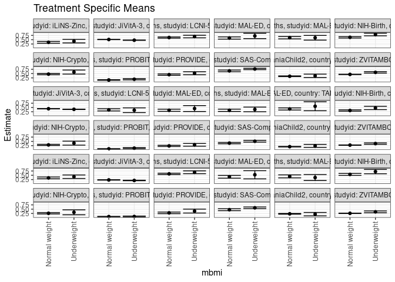

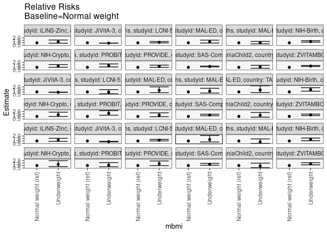

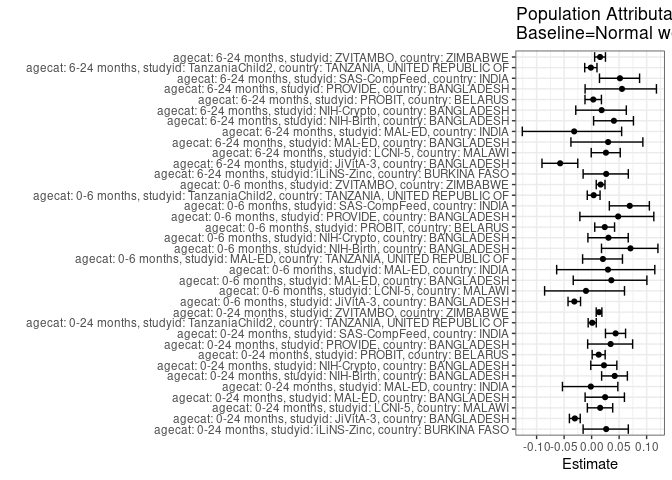

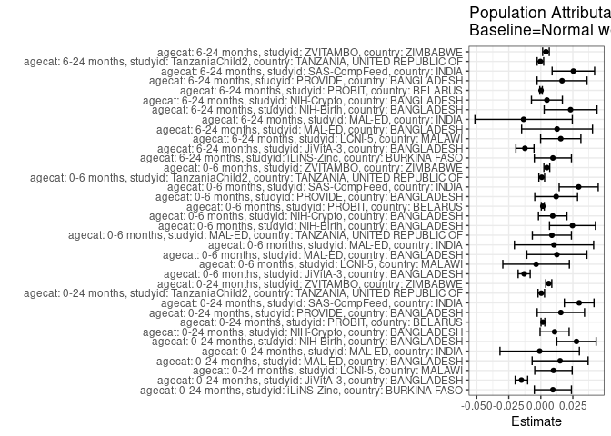

## Results Table

### Parameter: TSM

| agecat | studyid | country | intervention_level | baseline_level | estimate | ci_lower | ci_upper |
| --- | --- | --- | --- | --- | --- | --- | --- |
| 0-24 months | iLiNS-Zinc | BURKINA FASO | Normal weight | NA | 0.3472122 | 0.2944498 | 0.3999745 |
| 0-24 months | iLiNS-Zinc | BURKINA FASO | Underweight | NA | 0.4140969 | 0.3111351 | 0.5170587 |
| 0-24 months | JiVitA-3 | BANGLADESH | Normal weight | NA | 0.5106447 | 0.5012525 | 0.5200368 |
| 0-24 months | JiVitA-3 | BANGLADESH | Underweight | NA | 0.4711548 | 0.4603098 | 0.4819997 |
| 0-24 months | LCNI-5 | MALAWI | Normal weight | NA | 0.6257225 | 0.5896446 | 0.6618005 |
| 0-24 months | LCNI-5 | MALAWI | Underweight | NA | 0.6827586 | 0.6069616 | 0.7585557 |
| 0-24 months | MAL-ED | BANGLADESH | Normal weight | NA | 0.5990991 | 0.5345045 | 0.6636937 |
| 0-24 months | MAL-ED | BANGLADESH | Underweight | NA | 0.7187500 | 0.5626637 | 0.8748363 |
| 0-24 months | MAL-ED | INDIA | Normal weight | NA | 0.6165803 | 0.5478417 | 0.6853189 |
| 0-24 months | MAL-ED | INDIA | Underweight | NA | 0.6122449 | 0.4755380 | 0.7489518 |
| 0-24 months | NIH-Birth | BANGLADESH | Normal weight | NA | 0.6367113 | 0.5954598 | 0.6779628 |
| 0-24 months | NIH-Birth | BANGLADESH | Underweight | NA | 0.8018868 | 0.7259497 | 0.8778239 |
| 0-24 months | NIH-Crypto | BANGLADESH | Normal weight | NA | 0.4687045 | 0.4313644 | 0.5060446 |
| 0-24 months | NIH-Crypto | BANGLADESH | Underweight | NA | 0.5882353 | 0.4711826 | 0.7052880 |
| 0-24 months | PROBIT | BELARUS | Normal weight | NA | 0.1268459 | 0.1103845 | 0.1433073 |
| 0-24 months | PROBIT | BELARUS | Underweight | NA | 0.1701721 | 0.1333432 | 0.2070010 |
| 0-24 months | PROVIDE | BANGLADESH | Normal weight | NA | 0.4372694 | 0.3954769 | 0.4790618 |
| 0-24 months | PROVIDE | BANGLADESH | Underweight | NA | 0.5196850 | 0.4327281 | 0.6066420 |
| 0-24 months | SAS-CompFeed | INDIA | Normal weight | NA | 0.6566148 | 0.6070951 | 0.7061345 |
| 0-24 months | SAS-CompFeed | INDIA | Underweight | NA | 0.7678100 | 0.7296765 | 0.8059436 |
| 0-24 months | TanzaniaChild2 | TANZANIA, UNITED REPUBLIC OF | Normal weight | NA | 0.3450368 | 0.3254593 | 0.3646144 |
| 0-24 months | TanzaniaChild2 | TANZANIA, UNITED REPUBLIC OF | Underweight | NA | 0.3684211 | 0.2689869 | 0.4678552 |
| 0-24 months | ZVITAMBO | ZIMBABWE | Normal weight | NA | 0.4526983 | 0.4425826 | 0.4628141 |
| 0-24 months | ZVITAMBO | ZIMBABWE | Underweight | NA | 0.5705996 | 0.5279297 | 0.6132695 |
| 0-6 months | JiVitA-3 | BANGLADESH | Normal weight | NA | 0.4260203 | 0.4169475 | 0.4350930 |
| 0-6 months | JiVitA-3 | BANGLADESH | Underweight | NA | 0.3920981 | 0.3818452 | 0.4023511 |
| 0-6 months | LCNI-5 | MALAWI | Normal weight | NA | 0.3616071 | 0.2985710 | 0.4246432 |
| 0-6 months | LCNI-5 | MALAWI | Underweight | NA | 0.3404255 | 0.2047052 | 0.4761459 |
| 0-6 months | MAL-ED | BANGLADESH | Normal weight | NA | 0.3378378 | 0.2754982 | 0.4001775 |
| 0-6 months | MAL-ED | BANGLADESH | Underweight | NA | 0.4375000 | 0.2652814 | 0.6097186 |
| 0-6 months | MAL-ED | INDIA | Normal weight | NA | 0.3367876 | 0.2699727 | 0.4036024 |
| 0-6 months | MAL-ED | INDIA | Underweight | NA | 0.3877551 | 0.2510482 | 0.5244620 |
| 0-6 months | MAL-ED | TANZANIA, UNITED REPUBLIC OF | Normal weight | NA | 0.4132231 | 0.3510620 | 0.4753843 |
| 0-6 months | MAL-ED | TANZANIA, UNITED REPUBLIC OF | Underweight | NA | 0.5714286 | 0.3116959 | 0.8311612 |
| 0-6 months | NIH-Birth | BANGLADESH | Normal weight | NA | 0.3250478 | 0.2848731 | 0.3652225 |
| 0-6 months | NIH-Birth | BANGLADESH | Underweight | NA | 0.4716981 | 0.3765908 | 0.5668054 |
| 0-6 months | NIH-Crypto | BANGLADESH | Normal weight | NA | 0.2940320 | 0.2599404 | 0.3281236 |
| 0-6 months | NIH-Crypto | BANGLADESH | Underweight | NA | 0.3970588 | 0.2806874 | 0.5134302 |
| 0-6 months | PROBIT | BELARUS | Normal weight | NA | 0.0640666 | 0.0533879 | 0.0747453 |
| 0-6 months | PROBIT | BELARUS | Underweight | NA | 0.1051625 | 0.0751437 | 0.1351814 |
| 0-6 months | PROVIDE | BANGLADESH | Normal weight | NA | 0.2361624 | 0.2003792 | 0.2719456 |
| 0-6 months | PROVIDE | BANGLADESH | Underweight | NA | 0.2992126 | 0.2195134 | 0.3789118 |
| 0-6 months | SAS-CompFeed | INDIA | Normal weight | NA | 0.3970732 | 0.3591304 | 0.4350159 |
| 0-6 months | SAS-CompFeed | INDIA | Underweight | NA | 0.5065963 | 0.4549206 | 0.5582720 |
| 0-6 months | TanzaniaChild2 | TANZANIA, UNITED REPUBLIC OF | Normal weight | NA | 0.1920243 | 0.1758027 | 0.2082459 |
| 0-6 months | TanzaniaChild2 | TANZANIA, UNITED REPUBLIC OF | Underweight | NA | 0.2368421 | 0.1492053 | 0.3244789 |
| 0-6 months | ZVITAMBO | ZIMBABWE | Normal weight | NA | 0.2822086 | 0.2730564 | 0.2913607 |
| 0-6 months | ZVITAMBO | ZIMBABWE | Underweight | NA | 0.3713733 | 0.3297222 | 0.4130244 |
| 6-24 months | iLiNS-Zinc | BURKINA FASO | Normal weight | NA | 0.3472122 | 0.2944498 | 0.3999745 |
| 6-24 months | iLiNS-Zinc | BURKINA FASO | Underweight | NA | 0.4140969 | 0.3111351 | 0.5170587 |
| 6-24 months | JiVitA-3 | BANGLADESH | Normal weight | NA | 0.2287268 | 0.2163606 | 0.2410930 |
| 6-24 months | JiVitA-3 | BANGLADESH | Underweight | NA | 0.1979563 | 0.1846688 | 0.2112438 |
| 6-24 months | LCNI-5 | MALAWI | Normal weight | NA | 0.5827815 | 0.5434298 | 0.6221331 |
| 6-24 months | LCNI-5 | MALAWI | Underweight | NA | 0.6747967 | 0.5919533 | 0.7576402 |
| 6-24 months | MAL-ED | BANGLADESH | Normal weight | NA | 0.4113475 | 0.3298675 | 0.4928275 |
| 6-24 months | MAL-ED | BANGLADESH | Underweight | NA | 0.5294118 | 0.2913884 | 0.7674352 |
| 6-24 months | MAL-ED | INDIA | Normal weight | NA | 0.4354839 | 0.3479298 | 0.5230379 |
| 6-24 months | MAL-ED | INDIA | Underweight | NA | 0.3666667 | 0.1936635 | 0.5396698 |
| 6-24 months | NIH-Birth | BANGLADESH | Normal weight | NA | 0.5506757 | 0.4939264 | 0.6074250 |
| 6-24 months | NIH-Birth | BANGLADESH | Underweight | NA | 0.7142857 | 0.5876132 | 0.8409582 |
| 6-24 months | NIH-Crypto | BANGLADESH | Normal weight | NA | 0.2580645 | 0.2182539 | 0.2978751 |
| 6-24 months | NIH-Crypto | BANGLADESH | Underweight | NA | 0.3170732 | 0.1744952 | 0.4596512 |
| 6-24 months | PROBIT | BELARUS | Normal weight | NA | 0.0671201 | 0.0544214 | 0.0798187 |
| 6-24 months | PROBIT | BELARUS | Underweight | NA | 0.0726496 | 0.0471177 | 0.0981814 |
| 6-24 months | PROVIDE | BANGLADESH | Normal weight | NA | 0.2838542 | 0.2387094 | 0.3289990 |
| 6-24 months | PROVIDE | BANGLADESH | Underweight | NA | 0.3888889 | 0.2761610 | 0.5016168 |
| 6-24 months | SAS-CompFeed | INDIA | Normal weight | NA | 0.4685315 | 0.4130823 | 0.5239807 |
| 6-24 months | SAS-CompFeed | INDIA | Underweight | NA | 0.5789474 | 0.5313116 | 0.6265832 |
| 6-24 months | TanzaniaChild2 | TANZANIA, UNITED REPUBLIC OF | Normal weight | NA | 0.2283312 | 0.2071921 | 0.2494702 |
| 6-24 months | TanzaniaChild2 | TANZANIA, UNITED REPUBLIC OF | Underweight | NA | 0.2083333 | 0.1089524 | 0.3077142 |
| 6-24 months | ZVITAMBO | ZIMBABWE | Normal weight | NA | 0.2574947 | 0.2465844 | 0.2684051 |
| 6-24 months | ZVITAMBO | ZIMBABWE | Underweight | NA | 0.3444816 | 0.2906148 | 0.3983484 |

### Parameter: E(Y)

| agecat | studyid | country | intervention_level | baseline_level | estimate | ci_lower | ci_upper |
| --- | --- | --- | --- | --- | --- | --- | --- |
| 0-24 months | iLiNS-Zinc | BURKINA FASO | NA | NA | 0.3566542 | 0.3069876 | 0.4063208 |
| 0-24 months | JiVitA-3 | BANGLADESH | NA | NA | 0.4955174 | 0.4876719 | 0.5033630 |
| 0-24 months | LCNI-5 | MALAWI | NA | NA | 0.6356033 | 0.6029802 | 0.6682264 |
| 0-24 months | MAL-ED | BANGLADESH | NA | NA | 0.6141732 | 0.5541901 | 0.6741564 |
| 0-24 months | MAL-ED | INDIA | NA | NA | 0.6157025 | 0.5542897 | 0.6771153 |
| 0-24 months | NIH-Birth | BANGLADESH | NA | NA | 0.6645469 | 0.6276196 | 0.7014742 |
| 0-24 months | NIH-Crypto | BANGLADESH | NA | NA | 0.4794702 | 0.4438115 | 0.5151289 |
| 0-24 months | PROBIT | BELARUS | NA | NA | 0.1284965 | 0.1123633 | 0.1446297 |
| 0-24 months | PROVIDE | BANGLADESH | NA | NA | 0.4529148 | 0.4151667 | 0.4906629 |
| 0-24 months | SAS-CompFeed | INDIA | NA | NA | 0.6865672 | 0.6433613 | 0.7297731 |
| 0-24 months | TanzaniaChild2 | TANZANIA, UNITED REPUBLIC OF | NA | NA | 0.3454158 | 0.3261661 | 0.3646654 |
| 0-24 months | ZVITAMBO | ZIMBABWE | NA | NA | 0.4589062 | 0.4490494 | 0.4687630 |
| 0-6 months | JiVitA-3 | BANGLADESH | NA | NA | 0.4130330 | 0.4055721 | 0.4204940 |
| 0-6 months | LCNI-5 | MALAWI | NA | NA | 0.3579336 | 0.3007518 | 0.4151153 |
| 0-6 months | MAL-ED | BANGLADESH | NA | NA | 0.3503937 | 0.2916054 | 0.4091820 |
| 0-6 months | MAL-ED | INDIA | NA | NA | 0.3471074 | 0.2870050 | 0.4072099 |
| 0-6 months | MAL-ED | TANZANIA, UNITED REPUBLIC OF | NA | NA | 0.4218750 | 0.3612599 | 0.4824901 |
| 0-6 months | NIH-Birth | BANGLADESH | NA | NA | 0.3497615 | 0.3124631 | 0.3870600 |
| 0-6 months | NIH-Crypto | BANGLADESH | NA | NA | 0.3033113 | 0.2704998 | 0.3361228 |
| 0-6 months | PROBIT | BELARUS | NA | NA | 0.0656323 | 0.0549927 | 0.0762719 |
| 0-6 months | PROVIDE | BANGLADESH | NA | NA | 0.2481315 | 0.2153770 | 0.2808861 |
| 0-6 months | SAS-CompFeed | INDIA | NA | NA | 0.4266382 | 0.3925570 | 0.4607194 |
| 0-6 months | TanzaniaChild2 | TANZANIA, UNITED REPUBLIC OF | NA | NA | 0.1927505 | 0.1767818 | 0.2087193 |
| 0-6 months | ZVITAMBO | ZIMBABWE | NA | NA | 0.2869086 | 0.2779566 | 0.2958607 |
| 6-24 months | iLiNS-Zinc | BURKINA FASO | NA | NA | 0.3566542 | 0.3069876 | 0.4063208 |
| 6-24 months | JiVitA-3 | BANGLADESH | NA | NA | 0.2163480 | 0.2069669 | 0.2257290 |
| 6-24 months | LCNI-5 | MALAWI | NA | NA | 0.5983494 | 0.5626894 | 0.6340094 |
| 6-24 months | MAL-ED | BANGLADESH | NA | NA | 0.4240506 | 0.3467471 | 0.5013542 |
| 6-24 months | MAL-ED | INDIA | NA | NA | 0.4220779 | 0.3438191 | 0.5003367 |
| 6-24 months | NIH-Birth | BANGLADESH | NA | NA | 0.5739130 | 0.5216565 | 0.6261696 |
| 6-24 months | NIH-Crypto | BANGLADESH | NA | NA | 0.2628458 | 0.2244546 | 0.3012371 |
| 6-24 months | PROBIT | BELARUS | NA | NA | 0.0673219 | 0.0549549 | 0.0796890 |
| 6-24 months | PROVIDE | BANGLADESH | NA | NA | 0.3004386 | 0.2583143 | 0.3425629 |
| 6-24 months | SAS-CompFeed | INDIA | NA | NA | 0.4939435 | 0.4498186 | 0.5380683 |
| 6-24 months | TanzaniaChild2 | TANZANIA, UNITED REPUBLIC OF | NA | NA | 0.2280255 | 0.2072654 | 0.2487856 |
| 6-24 months | ZVITAMBO | ZIMBABWE | NA | NA | 0.2615147 | 0.2508057 | 0.2722237 |

### Parameter: RR

| agecat | studyid | country | intervention_level | baseline_level | estimate | ci_lower | ci_upper |
| --- | --- | --- | --- | --- | --- | --- | --- |
| 0-24 months | iLiNS-Zinc | BURKINA FASO | Normal weight | Normal weight | 1.0000000 | 1.0000000 | 1.0000000 |
| 0-24 months | iLiNS-Zinc | BURKINA FASO | Underweight | Normal weight | 1.1926337 | 0.9162253 | 1.5524294 |
| 0-24 months | JiVitA-3 | BANGLADESH | Normal weight | Normal weight | 1.0000000 | 1.0000000 | 1.0000000 |
| 0-24 months | JiVitA-3 | BANGLADESH | Underweight | Normal weight | 0.9226666 | 0.8988971 | 0.9470647 |
| 0-24 months | LCNI-5 | MALAWI | Normal weight | Normal weight | 1.0000000 | 1.0000000 | 1.0000000 |
| 0-24 months | LCNI-5 | MALAWI | Underweight | Normal weight | 1.0911523 | 0.9628462 | 1.2365562 |
| 0-24 months | MAL-ED | BANGLADESH | Normal weight | Normal weight | 1.0000000 | 1.0000000 | 1.0000000 |
| 0-24 months | MAL-ED | BANGLADESH | Underweight | Normal weight | 1.1997180 | 0.9414164 | 1.5288914 |
| 0-24 months | MAL-ED | INDIA | Normal weight | Normal weight | 1.0000000 | 1.0000000 | 1.0000000 |
| 0-24 months | MAL-ED | INDIA | Underweight | Normal weight | 0.9929686 | 0.7736559 | 1.2744512 |
| 0-24 months | NIH-Birth | BANGLADESH | Normal weight | Normal weight | 1.0000000 | 1.0000000 | 1.0000000 |
| 0-24 months | NIH-Birth | BANGLADESH | Underweight | Normal weight | 1.2594198 | 1.1228962 | 1.4125422 |
| 0-24 months | NIH-Crypto | BANGLADESH | Normal weight | Normal weight | 1.0000000 | 1.0000000 | 1.0000000 |
| 0-24 months | NIH-Crypto | BANGLADESH | Underweight | Normal weight | 1.2550237 | 1.0128922 | 1.5550367 |
| 0-24 months | PROBIT | BELARUS | Normal weight | Normal weight | 1.0000000 | 1.0000000 | 1.0000000 |
| 0-24 months | PROBIT | BELARUS | Underweight | Normal weight | 1.3415656 | 1.0683502 | 1.6846520 |
| 0-24 months | PROVIDE | BANGLADESH | Normal weight | Normal weight | 1.0000000 | 1.0000000 | 1.0000000 |
| 0-24 months | PROVIDE | BANGLADESH | Underweight | Normal weight | 1.1884780 | 0.9801738 | 1.4410505 |
| 0-24 months | SAS-CompFeed | INDIA | Normal weight | Normal weight | 1.0000000 | 1.0000000 | 1.0000000 |
| 0-24 months | SAS-CompFeed | INDIA | Underweight | Normal weight | 1.1693462 | 1.0922159 | 1.2519234 |
| 0-24 months | TanzaniaChild2 | TANZANIA, UNITED REPUBLIC OF | Normal weight | Normal weight | 1.0000000 | 1.0000000 | 1.0000000 |
| 0-24 months | TanzaniaChild2 | TANZANIA, UNITED REPUBLIC OF | Underweight | Normal weight | 1.0677731 | 0.8104080 | 1.4068707 |
| 0-24 months | ZVITAMBO | ZIMBABWE | Normal weight | Normal weight | 1.0000000 | 1.0000000 | 1.0000000 |
| 0-24 months | ZVITAMBO | ZIMBABWE | Underweight | Normal weight | 1.2604411 | 1.1658072 | 1.3627570 |
| 0-6 months | JiVitA-3 | BANGLADESH | Normal weight | Normal weight | 1.0000000 | 1.0000000 | 1.0000000 |
| 0-6 months | JiVitA-3 | BANGLADESH | Underweight | Normal weight | 0.9203744 | 0.8929389 | 0.9486529 |
| 0-6 months | LCNI-5 | MALAWI | Normal weight | Normal weight | 1.0000000 | 1.0000000 | 1.0000000 |
| 0-6 months | LCNI-5 | MALAWI | Underweight | Normal weight | 0.9414237 | 0.6092749 | 1.4546449 |
| 0-6 months | MAL-ED | BANGLADESH | Normal weight | Normal weight | 1.0000000 | 1.0000000 | 1.0000000 |
| 0-6 months | MAL-ED | BANGLADESH | Underweight | Normal weight | 1.2950000 | 0.8384207 | 2.0002189 |
| 0-6 months | MAL-ED | INDIA | Normal weight | Normal weight | 1.0000000 | 1.0000000 | 1.0000000 |
| 0-6 months | MAL-ED | INDIA | Underweight | Normal weight | 1.1513344 | 0.7682628 | 1.7254132 |
| 0-6 months | MAL-ED | TANZANIA, UNITED REPUBLIC OF | Normal weight | Normal weight | 1.0000000 | 1.0000000 | 1.0000000 |
| 0-6 months | MAL-ED | TANZANIA, UNITED REPUBLIC OF | Underweight | Normal weight | 1.3828571 | 0.8567351 | 2.2320714 |
| 0-6 months | NIH-Birth | BANGLADESH | Normal weight | Normal weight | 1.0000000 | 1.0000000 | 1.0000000 |
| 0-6 months | NIH-Birth | BANGLADESH | Underweight | Normal weight | 1.4511654 | 1.1455357 | 1.8383373 |
| 0-6 months | NIH-Crypto | BANGLADESH | Normal weight | Normal weight | 1.0000000 | 1.0000000 | 1.0000000 |
| 0-6 months | NIH-Crypto | BANGLADESH | Underweight | Normal weight | 1.3503931 | 0.9853201 | 1.8507302 |
| 0-6 months | PROBIT | BELARUS | Normal weight | Normal weight | 1.0000000 | 1.0000000 | 1.0000000 |
| 0-6 months | PROBIT | BELARUS | Underweight | Normal weight | 1.6414552 | 1.2400367 | 2.1728190 |
| 0-6 months | PROVIDE | BANGLADESH | Normal weight | Normal weight | 1.0000000 | 1.0000000 | 1.0000000 |
| 0-6 months | PROVIDE | BANGLADESH | Underweight | Normal weight | 1.2669783 | 0.9325724 | 1.7212971 |
| 0-6 months | SAS-CompFeed | INDIA | Normal weight | Normal weight | 1.0000000 | 1.0000000 | 1.0000000 |
| 0-6 months | SAS-CompFeed | INDIA | Underweight | Normal weight | 1.2758261 | 1.1301089 | 1.4403321 |
| 0-6 months | TanzaniaChild2 | TANZANIA, UNITED REPUBLIC OF | Normal weight | Normal weight | 1.0000000 | 1.0000000 | 1.0000000 |
| 0-6 months | TanzaniaChild2 | TANZANIA, UNITED REPUBLIC OF | Underweight | Normal weight | 1.2333967 | 0.8438583 | 1.8027521 |
| 0-6 months | ZVITAMBO | ZIMBABWE | Normal weight | Normal weight | 1.0000000 | 1.0000000 | 1.0000000 |
| 0-6 months | ZVITAMBO | ZIMBABWE | Underweight | Normal weight | 1.3159532 | 1.1709464 | 1.4789173 |
| 6-24 months | iLiNS-Zinc | BURKINA FASO | Normal weight | Normal weight | 1.0000000 | 1.0000000 | 1.0000000 |
| 6-24 months | iLiNS-Zinc | BURKINA FASO | Underweight | Normal weight | 1.1926337 | 0.9162253 | 1.5524294 |
| 6-24 months | JiVitA-3 | BANGLADESH | Normal weight | Normal weight | 1.0000000 | 1.0000000 | 1.0000000 |
| 6-24 months | JiVitA-3 | BANGLADESH | Underweight | Normal weight | 0.8654704 | 0.7960618 | 0.9409306 |
| 6-24 months | LCNI-5 | MALAWI | Normal weight | Normal weight | 1.0000000 | 1.0000000 | 1.0000000 |
| 6-24 months | LCNI-5 | MALAWI | Underweight | Normal weight | 1.1578899 | 1.0065080 | 1.3320400 |
| 6-24 months | MAL-ED | BANGLADESH | Normal weight | Normal weight | 1.0000000 | 1.0000000 | 1.0000000 |
| 6-24 months | MAL-ED | BANGLADESH | Underweight | Normal weight | 1.2870183 | 0.7874368 | 2.1035542 |
| 6-24 months | MAL-ED | INDIA | Normal weight | Normal weight | 1.0000000 | 1.0000000 | 1.0000000 |
| 6-24 months | MAL-ED | INDIA | Underweight | Normal weight | 0.8419753 | 0.5041505 | 1.4061721 |
| 6-24 months | NIH-Birth | BANGLADESH | Normal weight | Normal weight | 1.0000000 | 1.0000000 | 1.0000000 |
| 6-24 months | NIH-Birth | BANGLADESH | Underweight | Normal weight | 1.2971078 | 1.0565691 | 1.5924075 |
| 6-24 months | NIH-Crypto | BANGLADESH | Normal weight | Normal weight | 1.0000000 | 1.0000000 | 1.0000000 |
| 6-24 months | NIH-Crypto | BANGLADESH | Underweight | Normal weight | 1.2286585 | 0.7637827 | 1.9764807 |
| 6-24 months | PROBIT | BELARUS | Normal weight | Normal weight | 1.0000000 | 1.0000000 | 1.0000000 |
| 6-24 months | PROBIT | BELARUS | Underweight | Normal weight | 1.0823822 | 0.7396011 | 1.5840314 |
| 6-24 months | PROVIDE | BANGLADESH | Normal weight | Normal weight | 1.0000000 | 1.0000000 | 1.0000000 |
| 6-24 months | PROVIDE | BANGLADESH | Underweight | Normal weight | 1.3700306 | 0.9843215 | 1.9068809 |
| 6-24 months | SAS-CompFeed | INDIA | Normal weight | Normal weight | 1.0000000 | 1.0000000 | 1.0000000 |
| 6-24 months | SAS-CompFeed | INDIA | Underweight | Normal weight | 1.2356638 | 1.0633904 | 1.4358462 |
| 6-24 months | TanzaniaChild2 | TANZANIA, UNITED REPUBLIC OF | Normal weight | Normal weight | 1.0000000 | 1.0000000 | 1.0000000 |
| 6-24 months | TanzaniaChild2 | TANZANIA, UNITED REPUBLIC OF | Underweight | Normal weight | 0.9124174 | 0.5612510 | 1.4833032 |
| 6-24 months | ZVITAMBO | ZIMBABWE | Normal weight | Normal weight | 1.0000000 | 1.0000000 | 1.0000000 |
| 6-24 months | ZVITAMBO | ZIMBABWE | Underweight | Normal weight | 1.3378200 | 1.1377263 | 1.5731045 |

### Parameter: PAR

| agecat | studyid | country | intervention_level | baseline_level | estimate | ci_lower | ci_upper |
| --- | --- | --- | --- | --- | --- | --- | --- |
| 0-24 months | iLiNS-Zinc | BURKINA FASO | Normal weight | NA | 0.0094421 | -0.0050462 | 0.0239303 |
| 0-24 months | JiVitA-3 | BANGLADESH | Normal weight | NA | -0.0151272 | -0.0199965 | -0.0102580 |
| 0-24 months | LCNI-5 | MALAWI | Normal weight | NA | 0.0098808 | -0.0047351 | 0.0244967 |
| 0-24 months | MAL-ED | BANGLADESH | Normal weight | NA | 0.0150741 | -0.0067628 | 0.0369110 |
| 0-24 months | MAL-ED | INDIA | Normal weight | NA | -0.0008778 | -0.0318611 | 0.0301055 |
| 0-24 months | NIH-Birth | BANGLADESH | Normal weight | NA | 0.0278356 | 0.0124904 | 0.0431808 |
| 0-24 months | NIH-Crypto | BANGLADESH | Normal weight | NA | 0.0107657 | -0.0005666 | 0.0220979 |
| 0-24 months | PROBIT | BELARUS | Normal weight | NA | 0.0016506 | 0.0001827 | 0.0031185 |
| 0-24 months | PROVIDE | BANGLADESH | Normal weight | NA | 0.0156454 | -0.0028329 | 0.0341238 |
| 0-24 months | SAS-CompFeed | INDIA | Normal weight | NA | 0.0299524 | 0.0183825 | 0.0415223 |
| 0-24 months | TanzaniaChild2 | TANZANIA, UNITED REPUBLIC OF | Normal weight | NA | 0.0003789 | -0.0021575 | 0.0029153 |
| 0-24 months | ZVITAMBO | ZIMBABWE | Normal weight | NA | 0.0062079 | 0.0038409 | 0.0085748 |
| 0-6 months | JiVitA-3 | BANGLADESH | Normal weight | NA | -0.0129872 | -0.0176942 | -0.0082803 |
| 0-6 months | LCNI-5 | MALAWI | Normal weight | NA | -0.0036736 | -0.0296443 | 0.0222972 |
| 0-6 months | MAL-ED | BANGLADESH | Normal weight | NA | 0.0125559 | -0.0108758 | 0.0359875 |
| 0-6 months | MAL-ED | INDIA | Normal weight | NA | 0.0103199 | -0.0205979 | 0.0412377 |
| 0-6 months | MAL-ED | TANZANIA, UNITED REPUBLIC OF | Normal weight | NA | 0.0086519 | -0.0066061 | 0.0239098 |
| 0-6 months | NIH-Birth | BANGLADESH | Normal weight | NA | 0.0247137 | 0.0067929 | 0.0426345 |
| 0-6 months | NIH-Crypto | BANGLADESH | Normal weight | NA | 0.0092792 | -0.0018435 | 0.0204019 |
| 0-6 months | PROBIT | BELARUS | Normal weight | NA | 0.0015656 | 0.0004058 | 0.0027255 |
| 0-6 months | PROVIDE | BANGLADESH | Normal weight | NA | 0.0119692 | -0.0047212 | 0.0286596 |
| 0-6 months | SAS-CompFeed | INDIA | Normal weight | NA | 0.0295650 | 0.0143344 | 0.0447956 |
| 0-6 months | TanzaniaChild2 | TANZANIA, UNITED REPUBLIC OF | Normal weight | NA | 0.0007263 | -0.0015136 | 0.0029661 |
| 0-6 months | ZVITAMBO | ZIMBABWE | Normal weight | NA | 0.0047001 | 0.0024178 | 0.0069823 |
| 6-24 months | iLiNS-Zinc | BURKINA FASO | Normal weight | NA | 0.0094421 | -0.0050462 | 0.0239303 |
| 6-24 months | JiVitA-3 | BANGLADESH | Normal weight | NA | -0.0123788 | -0.0194567 | -0.0053010 |
| 6-24 months | LCNI-5 | MALAWI | Normal weight | NA | 0.0155679 | -0.0001508 | 0.0312866 |
| 6-24 months | MAL-ED | BANGLADESH | Normal weight | NA | 0.0127031 | -0.0149643 | 0.0403705 |
| 6-24 months | MAL-ED | INDIA | Normal weight | NA | -0.0134059 | -0.0514241 | 0.0246122 |
| 6-24 months | NIH-Birth | BANGLADESH | Normal weight | NA | 0.0232374 | 0.0026201 | 0.0438546 |
| 6-24 months | NIH-Crypto | BANGLADESH | Normal weight | NA | 0.0047813 | -0.0072953 | 0.0168579 |
| 6-24 months | PROBIT | BELARUS | Normal weight | NA | 0.0002019 | -0.0007926 | 0.0011964 |
| 6-24 months | PROVIDE | BANGLADESH | Normal weight | NA | 0.0165844 | -0.0029093 | 0.0360781 |
| 6-24 months | SAS-CompFeed | INDIA | Normal weight | NA | 0.0254120 | 0.0088364 | 0.0419877 |
| 6-24 months | TanzaniaChild2 | TANZANIA, UNITED REPUBLIC OF | Normal weight | NA | -0.0003057 | -0.0028487 | 0.0022373 |
| 6-24 months | ZVITAMBO | ZIMBABWE | Normal weight | NA | 0.0040199 | 0.0014413 | 0.0065986 |

### Parameter: PAF

| agecat | studyid | country | intervention_level | baseline_level | estimate | ci_lower | ci_upper |
| --- | --- | --- | --- | --- | --- | --- | --- |
| 0-24 months | iLiNS-Zinc | BURKINA FASO | Normal weight | NA | 0.0264740 | -0.0154665 | 0.0666822 |
| 0-24 months | JiVitA-3 | BANGLADESH | Normal weight | NA | -0.0305281 | -0.0403949 | -0.0207549 |
| 0-24 months | LCNI-5 | MALAWI | Normal weight | NA | 0.0155455 | -0.0077549 | 0.0383073 |
| 0-24 months | MAL-ED | BANGLADESH | Normal weight | NA | 0.0245438 | -0.0118432 | 0.0596222 |
| 0-24 months | MAL-ED | INDIA | Normal weight | NA | -0.0014257 | -0.0530338 | 0.0476531 |
| 0-24 months | NIH-Birth | BANGLADESH | Normal weight | NA | 0.0418866 | 0.0181811 | 0.0650197 |
| 0-24 months | NIH-Crypto | BANGLADESH | Normal weight | NA | 0.0224533 | -0.0015181 | 0.0458509 |
| 0-24 months | PROBIT | BELARUS | Normal weight | NA | 0.0128456 | 0.0009529 | 0.0245966 |
| 0-24 months | PROVIDE | BANGLADESH | Normal weight | NA | 0.0345439 | -0.0071926 | 0.0745508 |
| 0-24 months | SAS-CompFeed | INDIA | Normal weight | NA | 0.0436263 | 0.0251940 | 0.0617101 |
| 0-24 months | TanzaniaChild2 | TANZANIA, UNITED REPUBLIC OF | Normal weight | NA | 0.0010970 | -0.0062773 | 0.0084173 |
| 0-24 months | ZVITAMBO | ZIMBABWE | Normal weight | NA | 0.0135275 | 0.0083506 | 0.0186774 |
| 0-6 months | JiVitA-3 | BANGLADESH | Normal weight | NA | -0.0314436 | -0.0428803 | -0.0201322 |
| 0-6 months | LCNI-5 | MALAWI | Normal weight | NA | -0.0102633 | -0.0854924 | 0.0597522 |
| 0-6 months | MAL-ED | BANGLADESH | Normal weight | NA | 0.0358336 | -0.0334239 | 0.1004496 |
| 0-6 months | MAL-ED | INDIA | Normal weight | NA | 0.0297311 | -0.0635634 | 0.1148419 |
| 0-6 months | MAL-ED | TANZANIA, UNITED REPUBLIC OF | Normal weight | NA | 0.0205081 | -0.0163884 | 0.0560652 |
| 0-6 months | NIH-Birth | BANGLADESH | Normal weight | NA | 0.0706588 | 0.0179830 | 0.1205091 |
| 0-6 months | NIH-Crypto | BANGLADESH | Normal weight | NA | 0.0305931 | -0.0067560 | 0.0665566 |
| 0-6 months | PROBIT | BELARUS | Normal weight | NA | 0.0238548 | 0.0056757 | 0.0417015 |
| 0-6 months | PROVIDE | BANGLADESH | Normal weight | NA | 0.0482372 | -0.0213406 | 0.1130751 |
| 0-6 months | SAS-CompFeed | INDIA | Normal weight | NA | 0.0692976 | 0.0322095 | 0.1049644 |
| 0-6 months | TanzaniaChild2 | TANZANIA, UNITED REPUBLIC OF | Normal weight | NA | 0.0037679 | -0.0079388 | 0.0153386 |
| 0-6 months | ZVITAMBO | ZIMBABWE | Normal weight | NA | 0.0163817 | 0.0083984 | 0.0243008 |
| 6-24 months | iLiNS-Zinc | BURKINA FASO | Normal weight | NA | 0.0264740 | -0.0154665 | 0.0666822 |
| 6-24 months | JiVitA-3 | BANGLADESH | Normal weight | NA | -0.0572171 | -0.0902546 | -0.0251808 |
| 6-24 months | LCNI-5 | MALAWI | Normal weight | NA | 0.0260181 | -0.0006987 | 0.0520217 |
| 6-24 months | MAL-ED | BANGLADESH | Normal weight | NA | 0.0299566 | -0.0376377 | 0.0931477 |
| 6-24 months | MAL-ED | INDIA | Normal weight | NA | -0.0317618 | -0.1259906 | 0.0545815 |
| 6-24 months | NIH-Birth | BANGLADESH | Normal weight | NA | 0.0404894 | 0.0035743 | 0.0760368 |
| 6-24 months | NIH-Crypto | BANGLADESH | Normal weight | NA | 0.0181906 | -0.0288228 | 0.0630557 |
| 6-24 months | PROBIT | BELARUS | Normal weight | NA | 0.0029986 | -0.0120593 | 0.0178324 |
| 6-24 months | PROVIDE | BANGLADESH | Normal weight | NA | 0.0552007 | -0.0118700 | 0.1178258 |
| 6-24 months | SAS-CompFeed | INDIA | Normal weight | NA | 0.0514472 | 0.0143094 | 0.0871857 |
| 6-24 months | TanzaniaChild2 | TANZANIA, UNITED REPUBLIC OF | Normal weight | NA | -0.0013406 | -0.0125449 | 0.0097397 |
| 6-24 months | ZVITAMBO | ZIMBABWE | Normal weight | NA | 0.0153718 | 0.0054681 | 0.0251768 |